# Conjoint Analysis with Fashion data

Mark Preston

November 1, 2018

### Introduction: Understanding consumer fashion preferences using conjoint methods

For this assignment, I’ll be using the fashion data to perform conjoint analysis. The method helps develop an understanding for consumer preferences for different products. Using the data, I’ll try several different methods to ensure the best analytical solution can be found to aid the product concept development exercise. As a methodological note, there are 400 respondents here, each of whom have 8 responses to product designs.

```r
library(tidyverse)
library(gridExtra)
library(AlgDesign)
library(conjoint)
library(lme4)
library(knitr)
library(kableExtra)

#setting ggplot preference
theme_set(
  theme_minimal()
)

#custom table function
custom_kable <- function(x){
  kable(x, format = "html") %>%
    kable_styling(bootstrap_options = "striped")
}

fashion <- read.table("fashiondata.txt", sep = "", stringsAsFactors = F) %>%
  rename_all(tolower) %>%
  mutate(respondent = rep(1:400, each = 8)) %>%
  mutate_at(vars(fashion, quality, price), as.factor) %>%
  dplyr::select(respondent, everything())
```

### Exploratory Data Analysis: Reviewing consumer fashion preferences

Before the modelling phase, I’ll do an exploratory analysis to review the data I’m working with. As a starting point here, I’m doing a quick summary. It looks like the various attributes are balanced for price, quality, and fashion while the ratings are also fairly uniform. The data contains more women than men and also skews younger with the 16-24 age group as the largest.

```r
fashion %>%
  dplyr::select(-respondent) %>%
  summary() %>%
  custom_kable()
```

[output not shown]

[output not shown]

[output not shown]

[output not shown]

[output not shown]

[output not shown]

Given there are three product feature variables (fashion style, quality, and price), there are eight possible product design combinations. These combinations can be seen below. Each design option is balanced.

```r
fashion %>%
  count(fashion, quality, price) %>%
  custom_kable()
```

| fashion | quality | price | n |
| --- | --- | --- | --- |
| Modern | HighQual | HighPrice | 400 |
| Modern | HighQual | LowPrice | 400 |
| Modern | Low Qual | HighPrice | 400 |
| Modern | Low Qual | LowPrice | 400 |
| Traditional | HighQual | HighPrice | 400 |
| Traditional | HighQual | LowPrice | 400 |
| Traditional | Low Qual | HighPrice | 400 |
| Traditional | Low Qual | LowPrice | 400 |

Having seen the design combinations, I wanted to see an initial chart with each variable permutation and subsequent rating. To do so, I developed a faceted grid plot so all four variables, and their counts, could be reviewed at once. It appears, not surprisingly, that the consumers here have high ratings for low price, high quality, and modern options (n = 245). The second largest group is high price, low quality, and traditional options with a 1 rating (n = 242).

Those two don’t seem too surprising but, some other combinations stick out. For example, modern, low quality, and low price with a 5 rating has a fairly high concentration (n = 149). The traditional fashion option at high price in general do not seem popular either. None of these have been statistically validated but, the chart is a good first glance at the various combination preferences.

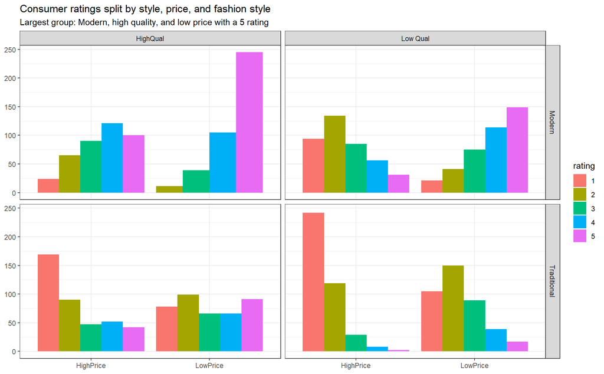

```r
fashion %>%
  count(fashion, quality, price, rating) %>%
  mutate(rating = as.character(rating)) %>%
  ggplot(aes(price, n, fill = rating)) +
  geom_col(position = "dodge") +
  facet_grid(fashion ~ quality) +
  theme_bw() +
  labs(title = "Consumer ratings split by style, price, and fashion style",
       subtitle = "Largest group: Modern, high quality, and low price with a 5 rating",
       x = NULL,
       y = NULL)
```

Another missing element from the initial fashion preference combinations is the consumer profile details. The added dimensions for age and gender present some visualization challenges but, I’ve created price, fashion, and quality charts for each and then displayed them in one grid so all six variables can be reviewed at once. Despite being slightly busy (and not appropriate for sharing directly with the business) it provides a first glimpse into the various consumer preferences by category. Young women really stick out here. The group seems to have low ratings for high prices, traditional clothes, and low quality (and high for low price, modern, high quality). Overall, this helps situate the product preferences for the consumer groups moving into the modelling phase.

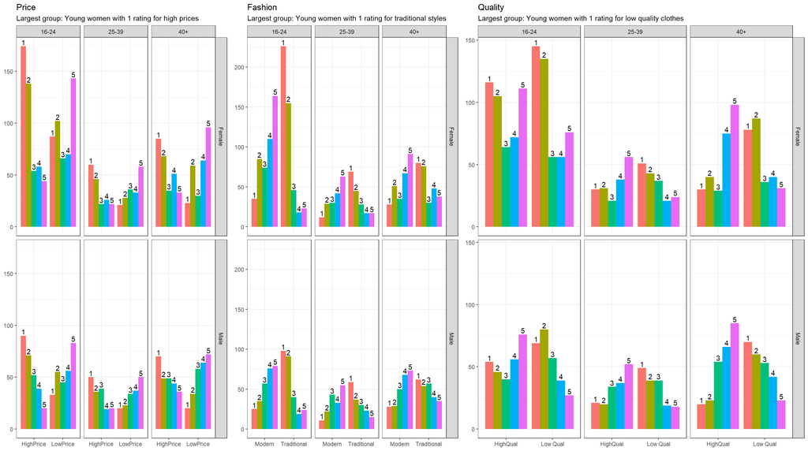

```r
price <- fashion %>%
  count(gender, age, price, rating) %>%
  mutate(rating = as.character(rating)) %>%
  ggplot(aes(price, n, fill = rating)) +
  geom_text(aes(label = rating), position = position_dodge(width = 0.9), vjust = -0.25) +
  geom_col(position = "dodge", show.legend = F) +
  facet_grid(gender ~ age) +
  theme_bw() +
  labs(title = "Price",
       subtitle = "Largest group: Young women with 1 rating for high prices",
       x = NULL,
       y = NULL)

fashion_panel <- fashion %>%
  count(gender, age, fashion, rating) %>%
  mutate(rating = as.character(rating)) %>%
  ggplot(aes(fashion, n, fill = rating)) +
  geom_text(aes(label = rating), position = position_dodge(width = 0.9), vjust = -0.25) +
  geom_col(position = "dodge",  show.legend = F) +
  facet_grid(gender ~ age) +
  theme_bw() +
  labs(title = "Fashion",
       subtitle = "Largest group: Young women with 1 rating for traditional styles",
       x = NULL,
       y = NULL)

quality <- fashion %>%
  count(gender, age, quality, rating) %>%
  mutate(rating = as.character(rating)) %>%
  ggplot(aes(quality, n, fill = rating)) +
  geom_text(aes(label = rating), position = position_dodge(width = 0.9), vjust = -0.25) +
  geom_col(position = "dodge", show.legend = F) +
  facet_grid(gender ~ age) +
  theme_bw() +
  labs(title = "Quality",
       subtitle = "Largest group: Young women with 1 rating for low quality clothes",
       x = NULL,
       y = NULL)

grid.arrange(price, fashion_panel, quality, nrow = 1, widths = c(2, 2, 3))
```

As another interest point, I wanted to see a top 10 for all the variables at once. The most populous design choice is young women who dislike low quality traditional clothing with a high price. For males, the largest count is for young men who have a high rating for modern, high quality, and low price fashion choices.

```r
fashion %>%
  count(gender, age, fashion, quality, price, rating) %>%
  arrange(desc(n)) %>%
  slice(1:10) %>%
  custom_kable()
```

| gender | age | fashion | quality | price | rating | n |
| --- | --- | --- | --- | --- | --- | --- |
| Female | 16-24 | Traditional | Low Qual | HighPrice | 1 | 76 |
| Female | 16-24 | Modern | HighQual | LowPrice | 5 | 69 |
| Female | 16-24 | Traditional | HighQual | HighPrice | 1 | 68 |
| Female | 16-24 | Modern | Low Qual | LowPrice | 5 | 58 |
| Female | 16-24 | Traditional | Low Qual | LowPrice | 2 | 47 |
| Female | 40+ | Modern | HighQual | LowPrice | 5 | 47 |
| Female | 16-24 | Traditional | Low Qual | LowPrice | 1 | 46 |
| Male | 16-24 | Modern | HighQual | LowPrice | 5 | 42 |
| Female | 16-24 | Modern | Low Qual | HighPrice | 2 | 41 |
| Female | 16-24 | Traditional | HighQual | LowPrice | 2 | 41 |

Finally, since the previous responses are all aggregated preferences by individual people, I’m highlighting one respondent’s preferences here. This person is a male aged 25-39 who appears to like the high quality modern options at either price point and the traditional high quality items at low costs. These ratings will be used for all the respondents in the modelling phase.

```r
fashion %>%
  filter(respondent == 1) %>%
  custom_kable()
```

| respondent | rating | fashion | quality | price | gender | age |
| --- | --- | --- | --- | --- | --- | --- |
| 1 | 1 | Traditional | Low Qual | HighPrice | Male | 25-39 |
| 1 | 3 | Traditional | Low Qual | LowPrice | Male | 25-39 |
| 1 | 3 | Traditional | HighQual | HighPrice | Male | 25-39 |
| 1 | 5 | Traditional | HighQual | LowPrice | Male | 25-39 |
| 1 | 2 | Modern | Low Qual | HighPrice | Male | 25-39 |
| 1 | 2 | Modern | Low Qual | LowPrice | Male | 25-39 |
| 1 | 5 | Modern | HighQual | HighPrice | Male | 25-39 |
| 1 | 5 | Modern | HighQual | LowPrice | Male | 25-39 |

### Conjoint in Action: Reviewing and quantifying consumer preferences

In this section, I’ll develop analyses using the following methods:

- Partworth estimation for the individual
- Partworth estimations by combining all individual responses
- Partworth estimation using a linear mixed model
- Partworth estimation of mixed effects using MCMC regression

Before getting to the modelling though, there are several data frames that need to be constructed. These include all the consumers preferences spread out in a matrix, a train and test model matrix data frame, and the factorial design.

```r
profiles <- c(seq(4, nrow(fashion), 8), seq(8, nrow(fashion), 8)) %>%
  as.data.frame() %>%
  rename(holdout = ".") %>%
  arrange(holdout)

mcmc_train <- fashion %>%
  dplyr::select(respondent, rating, fashion, quality, price) %>%
  model.matrix(~., data = .) %>%
  as.data.frame() %>%
  dplyr::select(-1) %>%
  filter(!row_number() %in% profiles$holdout) %>%
  mutate_all(function(x) ifelse(x == 0, -1, x))

mcmc_test <- fashion %>%
  dplyr::select(respondent, rating, fashion, quality, price) %>%
  model.matrix(~., data = .) %>%
  as.data.frame() %>%
  dplyr::select(-1) %>%
  filter(row_number() %in% profiles$holdout) %>%
  mutate_all(function(x) ifelse(x == 0, -1, x))

preference_training <- matrix(nrow = 400,
                              ncol = 8,
                              data = fashion$rating,
                              byrow = T) %>%
  as.data.frame()

factorial_designs <- gen.factorial(levels = c(2, 2, 2),
                                   nVars = 3,
                                   varNames = c("fashion", "quality", "price")) %>%
  mutate_all(as.factor)

design_model <- model.matrix(~fashion + quality + price, data = factorial_designs) %>%
  as.data.frame()
```

#### Individual Partworth Analysis

The first model will develop individual coefficients, called partworths, for each design variable. These values indicate which feature the consumer liked most or least. Taken together, an overall feature importance value can be derived for the respondent.

```r
holdout_profiles <- c(4, 8)

individual_partworth <- lm(t(preference_training)[-holdout_profiles,] ~.,
                           data = design_model[-holdout_profiles, -1])

concept_one_part <- lm(t(preference_training[1,]) ~., data = design_model)

summary(concept_one_part)
```

```
##
## Call:
## lm(formula = t(preference_training[1, ]) ~ ., data = design_model)
##
## Residuals:
##     1     2     3     4     5     6     7     8
## -0.25  0.75 -0.75  0.25  0.25 -0.75  0.75 -0.25
##
## Coefficients: (1 not defined because of singularities)
##               Estimate Std. Error t value Pr(>|t|)
## (Intercept)      1.250      0.559   2.236   0.0890 .
## `(Intercept)`       NA         NA      NA       NA
## fashion1         1.000      0.559   1.789   0.1481
## quality1         2.500      0.559   4.472   0.0111 *
## price1           0.500      0.559   0.894   0.4216
## ---
## Signif. codes:  0 '***' 0.001 '**' 0.01 '*' 0.05 '.' 0.1 ' ' 1
##
## Residual standard error: 0.7906 on 4 degrees of freedom
## Multiple R-squared:  0.8571, Adjusted R-squared:   0.75
## F-statistic:     8 on 3 and 4 DF,  p-value: 0.03639
```

To continue the importance focus, I’ve put together a data frame of the coefficients for every respondent. Since the second set of coefficients is absent, I’ve also added them in here as well. Given these features all have two levels, the second coefficients are just the opposite of the first. Using these, an overall importance metric for variable can be derived. I’ve included a histogram for each variable importance metric below. It appears quality has the largest concentration towards zero while price importance has the most dense output. This could signal it has the highest importance.

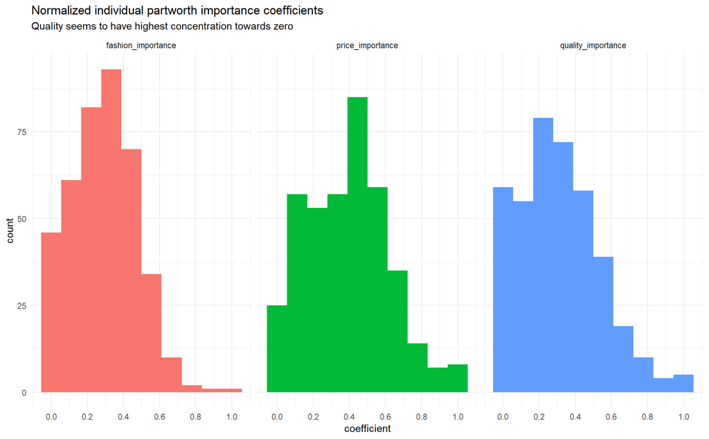

```r
partworth_analysis <- t(individual_partworth$coefficients) %>%
  as.data.frame() %>%
  dplyr::select(-1) %>%
  mutate(fashion2 = fashion1 * -1,
         quality2 = quality1 * -1,
         price2 = price1 * -1,
         fashion_importance = abs(fashion1) + abs(fashion2),
         quality_importance = abs(quality1) + abs(quality2),
         price_importance = abs(price1) + abs(price2))

partworth_sum <- partworth_analysis %>%
  dplyr::select(fashion_importance, quality_importance, price_importance) %>%
  rowSums()

partworth_analysis <- partworth_analysis %>%
  mutate_at(vars(fashion_importance,
                price_importance,
                quality_importance), function(x) x / partworth_sum)

partworth_analysis %>%
  dplyr::select(fashion_importance, quality_importance, price_importance) %>%
  gather(key = "variable", value = "coefficient") %>%
  ggplot(aes(coefficient, fill = variable)) +
  geom_histogram(bins = 10, show.legend = F) +
  facet_wrap(facets = "variable") +
  scale_x_continuous(breaks = seq(0, 1, .2)) +
  labs(title = "Normalized individual partworth importance coefficients",
       subtitle = "Quality seems to have highest concentration towards zero")
```

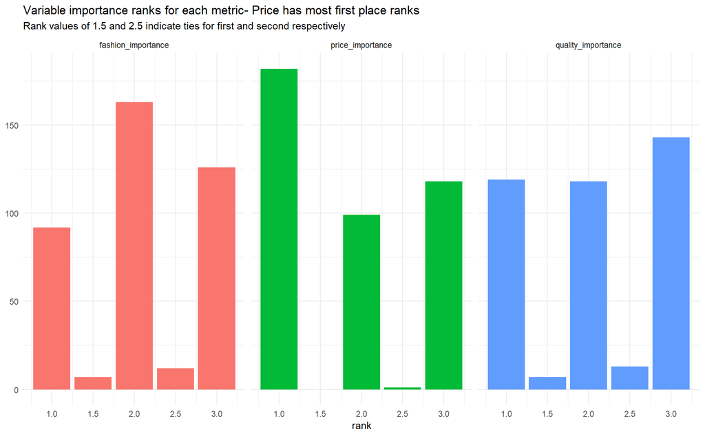

```r
partworth_analysis %>%
  dplyr::select(fashion_importance, price_importance, quality_importance) %>%
  apply(., 1, function(x) rank(- x)) %>%
  t() %>%
  as.data.frame() %>%
  gather(key = "variable", value = "rank") %>%
  count(variable, rank) %>%
  ggplot(aes(rank, n, fill = variable)) +
  geom_col(show.legend = F) +
  facet_wrap(facets = "variable") +
  labs(title = "Variable importance ranks for each metric- Price has most first place ranks",
       subtitle = "Rank values of 1.5 and 2.5 indicate ties for first and second respectively",
       y = NULL)
```

As a final review for this modelling approach, I want to check the R squared. This can be derived using the squared correlation between the fitted and actual values. With a value of .818, the metric is strong. I’ll use this for comparison moving forward to other methods.

```r
model_rsquared <- mcmc_train %>%
  mutate(individual = as.vector(individual_partworth$fitted.values)) %>%
  dplyr::select(rating, individual)

model_rsquared %>%
  summarise(model_R2 = round(cor(individual, rating) ^ 2, 3)) %>%
  kable(align = "left", format = "html") %>%
  kable_styling(bootstrap_options = "striped")
```

| model_R2 |
| --- |
| 0.818 |

#### Aggregated Individual Partworth Analysis

The aggregate approach simply takes the partworth importance values from the first model and averages the coefficients. Following this, the average rankings can be taken to ascertain which variable is the most impactful for the design.

In addition to the importance metric, the personal coefficient averages can be taken as well. This is essentially another way of looking at the importance metric but, each coefficient level can be seen here. A table of the values can be seen below, which shows price as the most impactful design feature.

```r
partworth_analysis %>%
  dplyr::select(-price_importance, -fashion_importance, -quality_importance) %>%
  gather(key = "level") %>%
  arrange(level) %>%
  mutate(variable = rep(names(fashion[c(3, 5, 4)]), each = 800)) %>%
  group_by(variable, level) %>%
  summarise(importance_mean = mean(value)) %>%
  custom_kable()
```

| variable | level | importance_mean |
| --- | --- | --- |
| fashion | fashion1 | 1.04625 |
| fashion | fashion2 | -1.04625 |
| price | price1 | 1.25250 |
| price | price2 | -1.25250 |
| quality | quality1 | 0.88875 |
| quality | quality2 | -0.88875 |

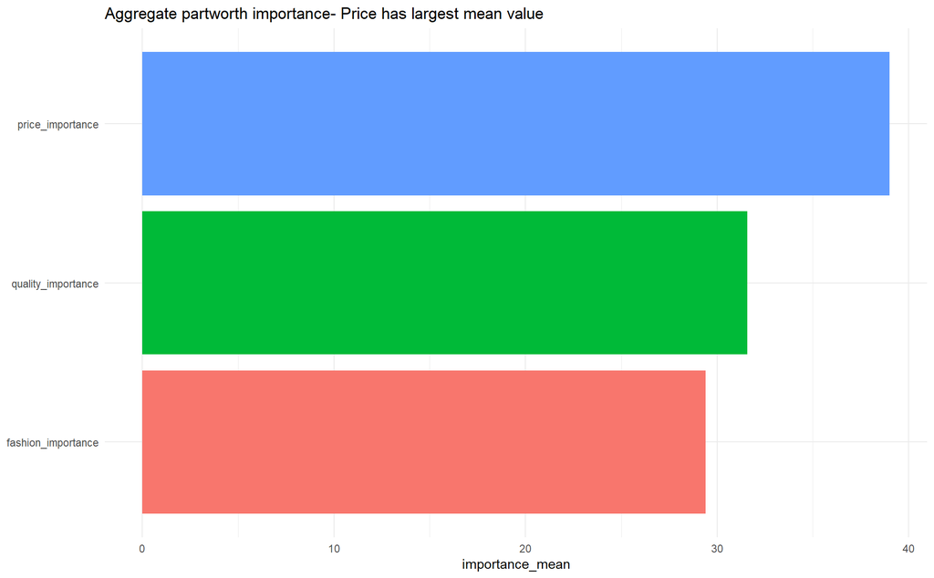

```r
partworth_analysis %>%
  dplyr::select(price_importance, fashion_importance, quality_importance) %>%
  gather(key = "variable") %>%
  group_by(variable) %>%
  summarise(importance_mean = mean(value) * 100) %>%
  mutate(variable = reorder(variable, importance_mean)) %>%
  ggplot(aes(variable, importance_mean, fill = variable)) +
  geom_col(show.legend = F) +
  coord_flip() +
  labs(title = "Aggregate partworth importance- Price has largest mean value",
       x = NULL)
```

```r
fashion_lm <- lm(rating ~ fashionTraditional + `qualityLow Qual` + priceLowPrice,
                 data = mcmc_train)

summary(fashion_lm)
```

```
##
## Call:
## lm(formula = rating ~ fashionTraditional + `qualityLow Qual` +
##     priceLowPrice, data = mcmc_train)
##
## Residuals:
##     Min      1Q  Median      3Q     Max
## -2.6788 -0.6325 -0.3800  0.6200  3.6200
##
## Coefficients:
##                    Estimate Std. Error t value Pr(>|t|)
## (Intercept)         2.97375    0.02903  102.44   <2e-16 ***
## fashionTraditional -0.62625    0.02370  -26.42   <2e-16 ***
## `qualityLow Qual`  -0.44437    0.02903  -15.31   <2e-16 ***
## priceLowPrice       0.52313    0.02903   18.02   <2e-16 ***
## ---
## Signif. codes:  0 '***' 0.001 '**' 0.01 '*' 0.05 '.' 0.1 ' ' 1
##
## Residual standard error: 1.161 on 2396 degrees of freedom
## Multiple R-squared:  0.3098, Adjusted R-squared:  0.309
## F-statistic: 358.6 on 3 and 2396 DF,  p-value: < 2.2e-16
```

#### Linear Mixed Model Partworth Analysis

The next model will be assessing rating using a linear mixed model. The method allows the effects of both individual consumers and group preferences to be explored. Here, I’ll use fixed effects, such that there are static coefficients for price, quality, and fashion type, alongside random effects.

```r
fashion_mixed <- lmer(rating ~ fashionTraditional + `qualityLow Qual` + priceLowPrice +
                        (1 + fashionTraditional + `qualityLow Qual` + priceLowPrice | respondent),
                      data = mcmc_train)
```

To highlight the fixed effects, I’ve put them into a table below. Notably, they are the same values as the aggregated linear model from the previous section. This highlights that these coefficients capture the broader group dynamic for preference.

```r
data.frame(fixef(fashion_mixed)) %>%
  rownames_to_column(var = "Variable") %>%
  rename(Fixed_value = fixef.fashion_mixed.) %>%
  custom_kable()
```

| Variable | Fixed_value |
| --- | --- |
| (Intercept) | 2.973750 |
| fashionTraditional | -0.626250 |
| `qualityLow Qual` | -0.444375 |
| priceLowPrice | 0.523125 |

The other set of coefficients here are random effects. These better capture the individual level preferences and are partworths for this model. Using a model with both sets permits some balance of group and individual preference to be reviewed.

```r
ranef(fashion_mixed)$respondent %>%
  as.data.frame() %>%
  head() %>%
  custom_kable()
```

| (Intercept) | fashionTraditional | `qualityLow Qual` | priceLowPrice |
| --- | --- | --- | --- |
| 0.2513072 | 0.3065671 | -0.4348777 | -0.0113072 |
| 0.4361990 | 0.4318529 | -0.6079424 | 0.1017164 |
| 0.3959863 | 0.3964185 | -0.5749073 | 0.0594729 |
| 0.3175284 | 0.3080116 | -0.4252154 | 0.0950627 |
| 0.2390704 | 0.2196046 | -0.2755235 | 0.1306525 |
| 0.1444408 | 0.0793113 | -0.1337209 | 0.0680484 |

Despite this added set of coefficients, the initial training R squared is lower than the individual partworth model.

```r
model_rsquared <- model_rsquared %>%
  mutate(mixed = predict(fashion_mixed))

model_rsquared %>%
  summarise(model_R2 = round(cor(mixed, rating) ^ 2, 3)) %>%
  kable(align = "left", format = "html") %>%
  kable_styling(bootstrap_options = "striped")
```

| model_R2 |
| --- |
| 0.603 |

#### Markov Chain Monte Carlo (MCMC) Partworth Analysis

The MCMC method here is similar to linear mixed model insofar as it includes both fixed and random coefficients. However, despite this congruence the models have different statistical foundations. MCMC is a Bayesian method that relies on simulation (Gibbs sampling) to derive coefficients. With the MCMC regression, the coefficients aren’t fixed using data but rather, estimated by sampling values from a distribution. In the model below, this means that the output includes 1000 simulations for intercept, price, quality, and fashion fixed effects in addition to random effects for each respondent (i.e. 400 values per simulation). Much like the linear mixed model, it accounts for a reasonable mix of group and personal preferences.

```r
library(MCMCpack)

fashion_mcmc <- MCMChregress(fixed = rating ~ fashionTraditional +
                               `qualityLow Qual` +
                               priceLowPrice,
                             random =  ~1 + fashionTraditional +
                               `qualityLow Qual` +
                               priceLowPrice,
                             r = 8,
                             R = 8,
                             data = mcmc_train,
                             group = "respondent",
                             verbose = 0)
```

```
##
## Running the Gibbs sampler. It may be long, keep cool :)
```

The initial R squared for the method is .797. For comparison, I’ve included all the model here where it is evident that the individual partworth approach has the highest coefficient for training.

```r
model_rsquared <- model_rsquared %>%
  mutate(mcmc = fashion_mcmc$Y.pred)

model_rsquared %>%
  summarise(individual_R2 = round(cor(individual, rating) ^ 2, 3),
            mixed_R2 = round(cor(mixed, rating) ^ 2, 3),
            mcmc_R2 = round(cor(mcmc, rating) ^ 2, 3)) %>%
  custom_kable()
```

| individual_R2 | mixed_R2 | mcmc_R2 |
| --- | --- | --- |
| 0.818 | 0.603 | 0.797 |

#### Assess the performance of the individual, mixed effects, and mcmc model using holdout

Prior to reviewing the holdout results for each model, there’s some set up that needs to be done. There’s no prediction function for the MCMC regression in this package so I’ll have to manually estimate the test ratings using the fixed and random effects from each simulation.

With this in mind, the estimation requires two broad set of values. First, the average value for each fixed effect coefficient to use as model constants. This applies to the intercept as well as each design feature. Second, the prediction requires a random effect value for each person by variable. Deriving this requires taking the average from each variable simulation run by respondent. The result of this process is shown in the table below. As seen, each respondent has both a fixed and random effect associated with their design preferences.

```r
mcmc_coef <- fashion_mcmc$mcmc %>%
  as.data.frame() %>%
  gather(key = "variable", value = "coef") %>%
  mutate(variable = str_replace(string = variable, pattern = "[\\(\\)]",
                                replacement = ""))

intercept_find <- grepl(pattern = "b.Intercept", x = mcmc_coef$variable)

quality_find <- grepl(pattern = "b.`qualityLow Qual`", x = mcmc_coef$variable)

fashion_find <- grepl(pattern = "b.fashionTraditional", x = mcmc_coef$variable)

price_find <- grepl(pattern = "b.priceLowPrice", x = mcmc_coef$variable)

mcmc_coef <- mcmc_coef %>%
  mutate(name = case_when(
   intercept_find ~ "Intercept",
   quality_find ~ "qualityLow",
   fashion_find ~ "fashionTrad",
   price_find ~ "priceLow"
  )
) %>%
  filter(!is.na(name))

mcmc_rand_means <- mcmc_coef %>%
  group_by(variable, name) %>%
  summarise(rand_mean = mean(coef)) %>%
  mutate(respondent = str_extract(string = variable, pattern = "[0-9]{1,3}"),
         respondent = as.numeric(respondent)) %>%
  spread(key = "name", value = "rand_mean")

mcmc_coef <- fashion_mcmc$mcmc %>%
  as.data.frame() %>%
  dplyr::select(1:4) %>%
  gather(key = "variable", value = "coef") %>%
  group_by(variable) %>%
  summarise(coef_means = mean(coef))

mcmc_means <- data.frame(
  respondent = unique(mcmc_rand_means$respondent),
  fixedIntercept = mcmc_coef$coef_means[1],
  Intercept = na.omit(mcmc_rand_means$Intercept),
  fixedTrad = mcmc_coef$coef_means[3],
  fashionTrad = na.omit(mcmc_rand_means$fashionTrad),
  fixedPrice = mcmc_coef$coef_means[4],
  priceLow = na.omit(mcmc_rand_means$priceLow),
  fixedQual = mcmc_coef$coef_means[2],
  qualityLow = na.omit(mcmc_rand_means$qualityLow)
)

mcmc_means %>%
  arrange(respondent) %>%
  head() %>%
  custom_kable()
```

| respondent | fixedIntercept | Intercept | fixedTrad | fashionTrad | fixedPrice | priceLow | fixedQual | qualityLow |
| --- | --- | --- | --- | --- | --- | --- | --- | --- |
| 1 | 2.973288 | 0.2006985 | -0.6266293 | 0.2661256 | 0.5232454 | -0.0595580 | -0.4442231 | -0.6234361 |
| 2 | 2.973288 | 0.8555616 | -0.6266293 | 0.5287543 | 0.5232454 | 0.4037474 | -0.4442231 | -0.7345920 |
| 3 | 2.973288 | 0.7016838 | -0.6266293 | 0.3968749 | 0.5232454 | 0.2490631 | -0.4442231 | -0.7448719 |
| 4 | 2.973288 | 0.7012013 | -0.6266293 | 0.3859489 | 0.5232454 | 0.4321248 | -0.4442231 | -0.5566805 |
| 5 | 2.973288 | 0.6831301 | -0.6266293 | 0.3706878 | 0.5232454 | 0.6109909 | -0.4442231 | -0.3241199 |
| 6 | 2.973288 | 0.4923300 | -0.6266293 | 0.0133799 | 0.5232454 | 0.4315469 | -0.4442231 | -0.3246619 |

Following this, I developed a function to streamline the test predictions. `mcmc_predict` puts together the fixed and random effects for each person and multiplies them by their test values for each variable.

The first five predictions from each method are shown below. At first glance, it appears the individual partworth performance does not translate well to the test scenario. The mixed effects model looks to be the best fit here, though this is a preliminary intuition.

```r
mcmc_predict <- function(n, x1, x2, x3){
  int <- (mcmc_means$fixedIntercept[n] + mcmc_means$Intercept[n])
  price <- (mcmc_means$fixedPrice[n] + mcmc_means$priceLow[n]) * x1
  qual <- (mcmc_means$fixedQual[n] + mcmc_means$qualityLow[n]) * x2
  fash <-  (mcmc_means$fixedTrad[n] + mcmc_means$fashionTrad[n]) * x3
  yhat <- int + price + qual + fash

  return(yhat)
}

model_predictions <- data.frame(
  actual = mcmc_test$rating,
  individual = as.vector(predict(individual_partworth,
                                 as.vector(design_model[holdout_profiles,]))),
  mixed = predict(fashion_mixed, mcmc_test),
  mcmc = mcmc_predict(n = mcmc_test$respondent,
                      x1 = mcmc_test$priceLowPrice,
                      x2 = mcmc_test$`qualityLow Qual`,
                      x3 = mcmc_test$fashionTraditional)
)

model_predictions %>%
  head(5) %>%
  custom_kable()
```

| actual | individual | mixed | mcmc |
| --- | --- | --- | --- |
| 5 | 4.666667 | 4.296445 | 4.344830 |
| 5 | 5.333333 | 4.935811 | 5.065837 |
| 5 | 7.000000 | 4.892711 | 2.965097 |
| 5 | 7.000000 | 5.281505 | 3.485627 |
| 4 | 6.333333 | 4.741785 | 5.174647 |

To make a more formal comparison, I’m using the mean squared error (MSE) which computes the average squared difference between two numeric vectors. The mixed effects model has the lowest value indicating the best fit on the holdout data.

```r
c(Mixed_mse = Metrics::mse(actual = model_predictions$actual,
                           predicted = model_predictions$mixed),
  Individual_mse = Metrics::mse(actual = model_predictions$actual,
                                predicted = model_predictions$individual),
   MCMC_mse = Metrics::mse(actual = model_predictions$actual,
                           predicted = model_predictions$mcmc)) %>%
  custom_kable()
```

| Mixed_mse | 0.992666 |
| --- | --- |
| Individual_mse | 2.311667 |
| MCMC_mse | 2.362199 |

### Clustering Mixed Effects Partworths to Define Benefit Segments

The mixed model partworths are the random effects. Essentially, these are the individual level preference coefficients for each design profile. Before moving into the clustering, I’m collecting the partworths and analyzing them to which variable stands out as having the highest importance. As seen in the plot, quality has the highest importance followed by fashion. Interestingly, price is the least important which could have very interesting business ramifications. With these rankings, I think the cluster means should be driven primarily by quality and fashion style.

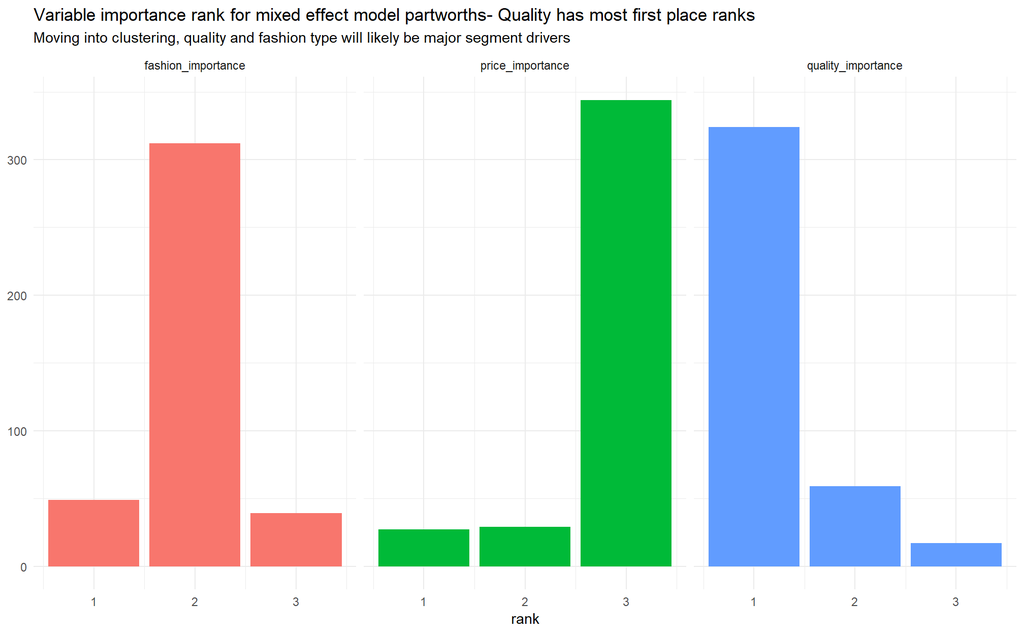

```r
rand_partworths <- ranef(fashion_mixed)$respondent %>%
  as.data.frame() %>%
  dplyr::select(-1) %>%
  rename(lowPrice = priceLowPrice,
         traditional = fashionTraditional,
         lowQual = "`qualityLow Qual`") %>%
  mutate(highPrice = lowPrice * -1,
         highQual = lowQual * -1,
         modern = traditional * -1,
         fashion_importance = abs(modern) + abs(traditional),
         quality_importance = abs(highQual) + abs(lowQual),
         price_importance = abs(highPrice) + abs(lowPrice))

partworth_sum <- rand_partworths %>%
  dplyr::select(fashion_importance, quality_importance, price_importance) %>%
  rowSums()

rand_partworths <- rand_partworths %>%
  mutate_at(vars(fashion_importance,
                 price_importance,
                 quality_importance), function(x) x / partworth_sum)

rand_partworths %>%
  dplyr::select(fashion_importance, price_importance, quality_importance) %>%
  apply(., 1, function(x) rank(- x)) %>%
  t() %>%
  as.data.frame() %>%
  gather(key = "variable", value = "rank") %>%
  count(variable, rank) %>%
  ggplot(aes(rank, n, fill = variable)) +
  geom_col(show.legend = F) +
  facet_wrap(facets = "variable") +
  labs(title = "Variable importance rank for mixed effect model partworths- Quality has most first place ranks",
       subtitle = "Moving into clustering, quality and fashion type will likely be major segment drivers",
       y = NULL)
```

Moving into the clustering, I’m making a train and test split so the results can be verified on a holdout set. My initial task is the pick an appropriate number of clusters but, this comes with a caveat. The benefit segments need to be driven by the business so any final approaches need to be verified with the product stakeholders. As such, I’d make a recommendation for cluster size but, would ultimately let the business drive any final cluster numbers. The variance accounted for (VAF) scree plot shows somewhere between 3 and 6 being reasonable. Additionally, the train and test VAF align, which provides assurances that the approach is sound in holdout.

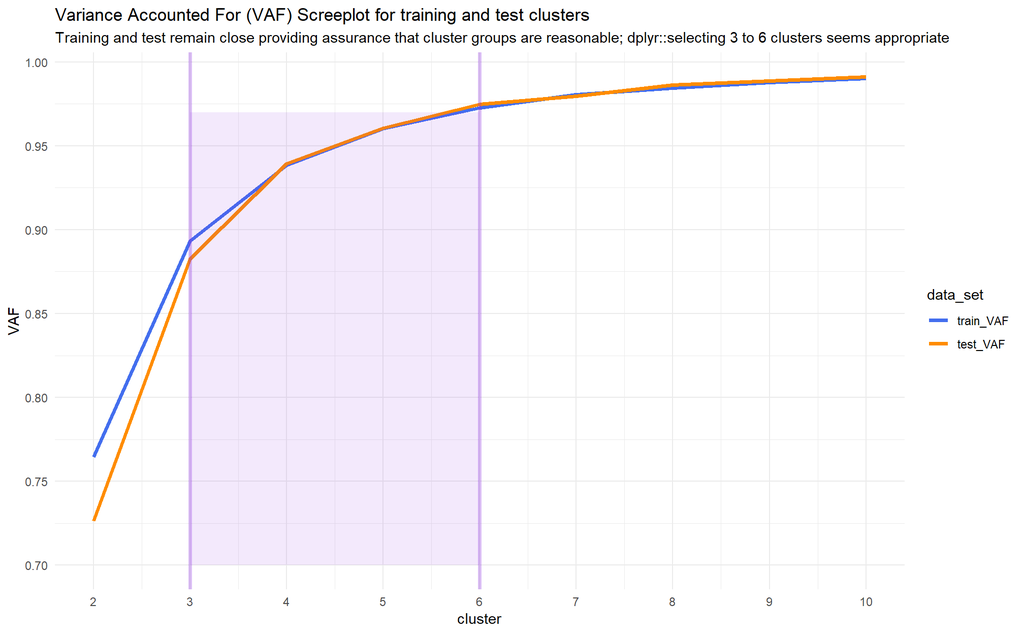

```r
set.seed(1017)
data_split <- sample(x = nrow(rand_partworths),
                     size = nrow(rand_partworths) * .7,
                     replace = F)

training <- rand_partworths %>%
  mutate(respondent = seq(1, n(), 1)) %>%
  slice(data_split)

testing <- rand_partworths %>%
  mutate(respondent = seq(1, n(), 1)) %>%
  slice(-data_split)

cluster_collect <- function(return, training_data, test_data, cluster_n, n_start, seed){
  set.seed(seed = seed)
  train_cluster <- kmeans(training_data, centers = cluster_n, nstart = n_start)
  test_cluster <- kmeans(test_data, centers = train_cluster$centers, nstart = n_start)

  vaf <- data.frame(cluster = cluster_n,
             train_VAF = 1 - train_cluster$tot.withinss / train_cluster$totss,
             test_VAF = 1 - test_cluster$tot.withinss / test_cluster$totss) %>%
    mutate(total_diff = round(test_VAF - train_VAF, 3),
           percent_diff = round(total_diff / train_VAF * 100, 3))

  train_size <- train_cluster$cluster
  test_size <- test_cluster$cluster

  if (return == "vaf") {return(vaf)}
  if (return == "test") {return(test_size)}
  if (return == "train") {return(train_size)}
  if (return != "vaf" | return != "test" | return != "train") {
    stop("Value specified is not part of function- Call one of vaf, train, or test")}
}

vaf_compare <- map_df(2:10, function(x) cluster_collect(seed = 1017,
                                             return = "vaf",
                                             training_data = training,
                                             test_data = testing,
                                             cluster_n = x,
                                             n_start = 100))

vaf_compare %>%
  dplyr::select(-total_diff, -percent_diff) %>%
  gather(key = data_set, value = vaf, train_VAF:test_VAF) %>%
  mutate(data_set = factor(data_set, levels = c("train_VAF", "test_VAF"))) %>%
  ggplot(aes(cluster, vaf, colour = data_set)) +
  geom_line(size = 1.3) +
  scale_y_continuous(breaks = seq(0, 1, .05)) +
  scale_x_continuous(breaks = seq(2, 10, 1)) +
  geom_vline(xintercept = 3, alpha = .3, colour = "blueviolet", size = 1.3) +
  geom_vline(xintercept = 6, alpha = .3, colour = "blueviolet", size = 1.3) +
  annotate("rect", xmin = 3, xmax = 6,
           ymin = .7, ymax = .97,
           alpha = .1, fill = "blueviolet") +
  scale_color_manual(values = c("royalblue2", "darkorange")) +
  labs(title = "Variance Accounted For (VAF) Screeplot for training and test clusters",
       subtitle = "Training and test remain close providing assurance that cluster groups are reasonable; dplyr::selecting 3 to 6 clusters seems appropriate",
       y = "VAF")
```

Another useful method for reviewing the cluster composition is visualization. For this, I’ve orthogonalized the partworths using principle components analysis (PCA) and taken the first two component factor scores. This dimensional reduction permits the clusters to be reviewed using a plot.

```r
comparison_df <- map(2:10, function(x) cluster_collect(seed = 1017,
                                                       return = "train",
                                                       training_data = training,
                                                       test_data = testing,
                                                       cluster_n = x,
                                                       n_start = 100)) %>%
  as.data.frame() %>%
  rename_all(function(x) paste0("CL", rep(2:10, each = 1))) %>%
  mutate(data_set = "training",
         F1_scores = princomp(training)$scores[,1],
         F2_scores = princomp(training)$scores[,2]) %>%
  dplyr::select(data_set, F1_scores, F2_scores, everything())

comparison_df <- comparison_df %>%
  bind_rows(
    map(2:10, function(x) cluster_collect(seed = 1017,
                                          return = "test",
                                          training_data = training,
                                          test_data = testing,
                                          cluster_n = x,
                                          n_start = 100)) %>%
  as.data.frame() %>%
  rename_all(function(x) paste0("CL", rep(2:10, each = 1))) %>%
  mutate(data_set = "testing",
         F1_scores = princomp(testing)$scores[,1],
         F2_scores = princomp(testing)$scores[,2]) %>%
  dplyr::select(data_set, F1_scores, F2_scores, everything())
)


comparison_df %>%
  head() %>%
  custom_kable()
```

| data_set | F1_scores | F2_scores | CL2 | CL3 | CL4 | CL5 | CL6 | CL7 | CL8 | CL9 | CL10 |
| --- | --- | --- | --- | --- | --- | --- | --- | --- | --- | --- | --- |
| training | 187.40783 | -0.0404144 | 2 | 3 | 3 | 2 | 6 | 6 | 5 | 2 | 2 |
| training | 106.41027 | -1.0837411 | 2 | 3 | 3 | 4 | 3 | 3 | 2 | 1 | 10 |
| training | -65.59456 | 0.6226226 | 1 | 1 | 4 | 5 | 1 | 2 | 6 | 8 | 4 |
| training | -128.59411 | 0.3642528 | 1 | 1 | 1 | 3 | 1 | 1 | 8 | 7 | 6 |
| training | -126.59300 | -0.1475525 | 1 | 1 | 1 | 3 | 1 | 1 | 8 | 7 | 6 |
| training | -56.59498 | 0.7956031 | 1 | 2 | 4 | 5 | 2 | 2 | 6 | 3 | 4 |

Examining the train and test split, I’m confident that the model translates well to holdout given the similar cluster size and composition. From a business perspective, it’s also good to see such a clean split between groups. This limited overlap ensures that each benefit segment has broadly homogeneous design preferences.

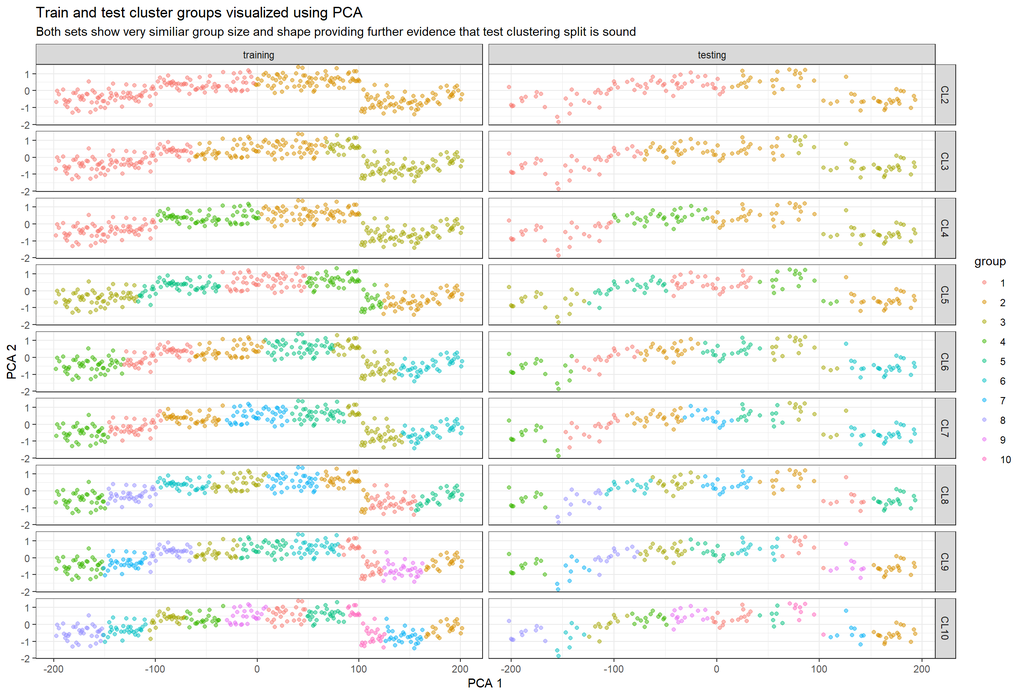

```r
comparison_df %>%
  gather(key = "cluster", value = "group", -data_set, -F1_scores, -F2_scores) %>%
  mutate(data_set = factor(data_set, levels = c("training", "testing")),
         group = as.factor(group),
         cluster = factor(cluster, levels = names(comparison_df)[4:12])) %>%
  ggplot(aes(F1_scores, F2_scores, colour = group)) +
  geom_jitter(alpha = .5) +
  facet_grid(cluster ~ data_set, scales = "free") +
  theme_bw() +
  labs(title = "Train and test cluster groups visualized using PCA",
       subtitle = "Both sets show very similiar group size and shape providing further evidence that test clustering split is sound",
       x = "PCA 1",
       y = "PCA 2")
```

The reason I chose five segments is because the clustering, regardless of k choice, produces three basic groups: low quality modern, high quality traditional, and preference agnostic. The output for this k can be verified below.

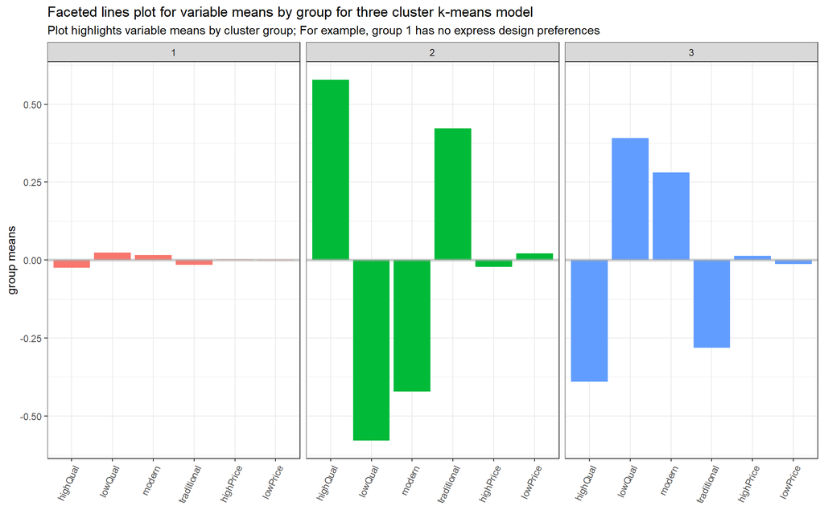

```r
set.seed(1017)
three_segments <- training %>%
  dplyr::select(1:6) %>%
  kmeans(., centers = 3, nstart = 100)

var_levels <- c("highQual", "lowQual", "modern", "traditional", "highPrice", "lowPrice")

as.data.frame(three_segments$centers) %>%
  mutate(Group = 1:3) %>%
  dplyr::select(Group, everything()) %>%
  gather(key = "variable", value = "means", -Group) %>%
  mutate(Group = as.factor(Group),
         variable = factor(variable, levels = var_levels)) %>%
  ggplot(aes(variable, means, fill = Group)) +
  geom_col(show.legend = F) +
  geom_hline(yintercept = 0, size = 1.3, alpha = .5, colour = "darkgray") +
  facet_wrap(facets = "Group", nrow = 1) +
  scale_y_continuous(breaks = seq(-1, 1, .25)) +
  theme_bw() +
  theme(axis.text.x = element_text(angle = 65, hjust = 1)) +
  labs(title = "Faceted lines plot for variable means by group for three cluster k-means model",
   subtitle = "Plot highlights variable means by cluster group; For example, group 1 has no express design preferences",
   y = "group means",
   x = NULL)
```

Any of the k variants I tried subdivided these high levels groups. Given this result, I felt five was appropriate because it adds nuance to each fashion conscious group while not splitting the agnostic consumers any further. This leaves a dedicated and light consumers segment for both low quality modern and high quality traditional. My other preference here would be the initial three segment split.

As a methodological note, I also tried the clustering with only three partworths instead of all six given they are just mirrored values. While the end results do not change between three and six approaches, I chose six so the visualization and interpretation is clearer. Including all six allows for independent review of each variable which ensures that the initial three do not need to be thought of as two variables at the same time. Additionally, the means are consistent and do not show any conflicts (for example, both high for modern and traditional). Overall, I preferred this approach due to better interpretation.

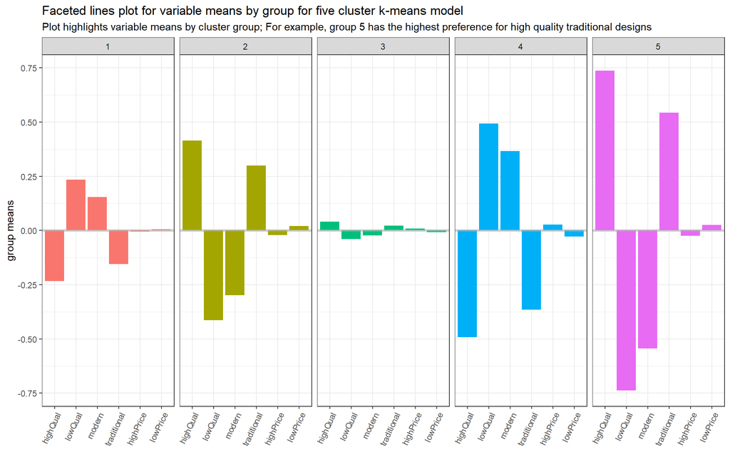

```r
set.seed(1017)
five_segments <- training %>%
  dplyr::select(1:6) %>%
  kmeans(., centers = 5, nstart = 100)

as.data.frame(five_segments$centers) %>%
  mutate(Group = 1:5) %>%
  dplyr::select(Group, everything()) %>%
  gather(key = "variable", value = "means", -Group) %>%
  mutate(Group = as.factor(Group),
         variable = factor(variable, levels = var_levels)) %>%
  ggplot(aes(variable, means, fill = Group)) +
  geom_col(show.legend = F) +
  geom_hline(yintercept = 0, size = 1.3, alpha = .5, colour = "darkgray") +
  facet_wrap(facets = "Group", nrow = 1) +
  scale_y_continuous(breaks = seq(-1, 1, .25)) +
  theme_bw() +
  theme(axis.text.x = element_text(angle = 65, hjust = 1)) +
  labs(title = "Faceted lines plot for variable means by group for five cluster k-means model",
   subtitle = "Plot highlights variable means by cluster group; For example, group 5 has the highest preference for high quality traditional designs",
   y = "group means",
   x = NULL)
```

Taking a quick step back, I’m highlighting the PCA cluster visualization again but, just for the five cluster approach. This just reconfirms that the clusters seem to be independent of one another with little overlap.

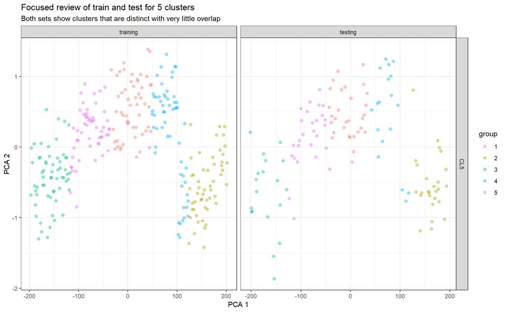

```r
comparison_df %>%
  gather(key = "cluster", value = "group", -data_set, -F1_scores, -F2_scores) %>%
  mutate(data_set = factor(data_set, levels = c("training", "testing")),
         group = as.factor(group)) %>%
  filter(cluster == "CL5") %>%
  ggplot(aes(F1_scores, F2_scores, colour = group)) +
  geom_jitter(size = 2, alpha = .4) +
  facet_grid(cluster ~ data_set, scales = "free") +
  theme_bw() +
  labs(title = "Focused review of train and test for 5 clusters",
       subtitle = "Both sets show clusters that are distinct with very little overlap",
       x = "PCA 1",
       y = "PCA 2")
```

### Driving Business Value: Naming final segments and reviewing marketing activities

With the segments developed, the analysis shifts from technical to business focused. One of the clear objectives here is to name the new benefit segments and then assess how many consumers fall into each group. Based on the mean values from each cluster, as derived from the visualizations, I’ve named each segment below. As aforementioned, this means that each fashion conscious class has a light and dedicated segment while the final group is more consumers without express preference for any design feature.

The light low quality modern cluster has the largest number of consumers (n = 85). Preference agnostic consumers are probably the least interesting group from a marketing perspective but, have the second highest cluster size. Each dedicated group is also small, which is likely a reflection of having fewer people with these more extreme design preferences.

```r
final_naming_set <- training %>%
  dplyr::select(respondent, quality_importance, fashion_importance, price_importance) %>%
  mutate(benefit_segment = five_segments$cluster,
         segment_name = case_when(
        benefit_segment == 1 ~ "Light LowQual & Modern",
        benefit_segment == 2 ~ "Light HighQual & Traditional",
        benefit_segment == 3 ~ "Preference Agnostic",
        benefit_segment == 4 ~ "Dedicated LowQual & Modern",
        benefit_segment == 5 ~ "Dedicated HighQual & Traditional"
         )
       ) %>%
  inner_join(x = ., y = fashion, by = "respondent") %>%
  dplyr::select(-fashion, -price, -quality, -rating) %>%
  filter(!duplicated(respondent))

final_naming_set %>%
  count(benefit_segment, segment_name) %>%
  mutate(total_percent = round(n / sum(n) * 100, 2)) %>%
  dplyr::select(benefit_segment, segment_name, n, total_percent) %>%
  custom_kable()
```

| benefit_segment | segment_name | n | total_percent |
| --- | --- | --- | --- |
| 1 | Light LowQual & Modern | 85 | 30.36 |
| 2 | Light HighQual & Traditional | 39 | 13.93 |
| 3 | Preference Agnostic | 74 | 26.43 |
| 4 | Dedicated LowQual & Modern | 46 | 16.43 |
| 5 | Dedicated HighQual & Traditional | 36 | 12.86 |

To further enrich this analysis, I also merged the naming set with the initial fashion data so I could ascertain which demographic characteristics each benefit was associated with. The young women stand out as having design preference for low quality and modern looks. Women as a whole seem less agnostic towards their fashion preferences when compared to men as well. In fact, preference agnostic is the largest count in every male age group and especially pronounced amongst young men. This chart could be used to evaluate what marketing activities would be reasonable to target for a certain demographic.

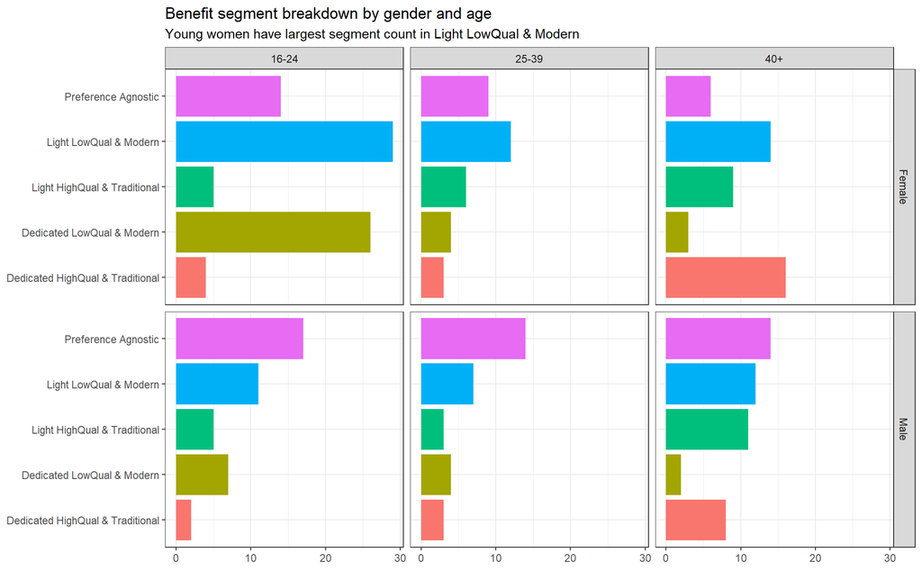

```r
final_naming_set %>%
  count(segment_name, gender, age) %>%
  ggplot(aes(segment_name, n, fill = segment_name)) +
  geom_col(show.legend = F) +
  facet_grid(gender ~ age) +
  theme_bw() +
  coord_flip() +
  labs(title = "Benefit segment breakdown by gender and age",
       subtitle = "Young women have largest segment count in Light LowQual & Modern",
       y = NULL,
       x = NULL)
```

#### Business reflections: Evaluating marketing decisions based on results

With the segments developed and named, I think the firm has numerous options for next steps. At the more competitive level, the segments could be further enriched with more data. Specifically, developing a survey to gather responses on attitudes, buying habits, lifestyle, and fashion needs would equip segments that were comprehensive on product and general consumer insights. This would be a powerful combination and would situate the firm well at the competitive level for their fashion product category.

Based on these results, the firm might also want to evaluate their product offering. For example, the results seem to suggest offering fashion lines for low quality modern and high quality traditional makes sense. There would likely be room for a much more mixed line to appeal to agnostic consumers, which would be especially attractive in the men’s line. Of course, these would all have to align with a wider brand image and marketing approach but, product mix could be refined using these results. It would be important to ask if the results conform to what the company thought about their design mix as well.

Moving into tactical activities, the new segments would be useful for promotions and targeted product launches. Since the design preferences are known, specific fashion lines could be targeted to consumers in specific demographic groups. For example, the 40+ female group had the highest concentration of dedicated high quality and traditional consumers. This group could be given insider sales on new, high end fashion designs. The same concept holds for launching new lines in the respective style and quality combinations. Given the basic consumer demographics are known, the appropriate marketing channel could be evaluated here as well (i.e matching medium to respondents).

Something I would be interested in during the tactical promotions and product launches would be pricing. The mixed partworths showed pricing as the least important metric. I’d be interested in trying to gauge price sensitivities with more detail using AB testing or some experimental design. From a business perspective, I’m weary of young respondents not being slightly cost conscious. This would be an opportunity to further refine the segments and evaluate how well the solution performs in practice.

Overall, the series of modelling approaches showed that using this fashion data, the mixed effects model was most effective producing a result with the lowest error metric. The end result is a reasonable set of benefit clusters which have business relevance. Their ultimate value would need to be reviewed in close conjunction with the firm’s product team so that the marketing activities match any wider company goals. The work would need to be further refined using business input but, this would be a sound starting point for defining these design-based clusters for the fashion company.